# Bloomberg Businessweek’s College Rankings - 2021

Tural Sadigov (and Courtney Gibbons)

2/3/2022 (updated 2/12/2025)

# Question of interest

- **Can we reproduce Bloomberg Businessweek’s MBA college ranking?**
- Dr. Anjani Jain (Yale)

# Bloomberg data & methodology - 2021 ranking

- 119 MBA programs (we will look at the first 84)
- Five variables: Compensation, Learning, Networking, Entrepreneurship, Diversity
- Weights for the categories are crowd-sourced
- Surveys: students, alumni, recruiters
- Key claim: It is intentionally not reproducible!
- https://www.bloomberg.com/business-schools/methodology

# Data collection and variable creation

- Survey - each variable: 1-7
- Raw scores weighted
- Weighted sum: 1-7
- Weighted sum is scaled to 0 - 100 (‘normalized’)
- Minimum –> 0, Maximum –> 100
- Transformation: $T(x) = \frac{100}{x_{(n)} - x_{(1)}} (x - x_{(1)})$
- Crowd-sourced weights are

```
##     Compensation         Learning       Networking Entrepreneurship
##            0.357            0.258            0.178            0.120
##        Diversity
##            0.086
```

# Toy example - do transformations as Businessweek

```
##  Comp Lear Comp_weigthed Lear_weighted w_sum scaled_w_sum
##     2    5           1.2           2.0   3.2      0.00000
##     3    6           1.8           2.4   4.2     83.33333
##     4    5           2.4           2.0   4.4    100.00000
```

```
## Compensation     Learning
##          0.6          0.4
```

```
## Variance of Compensation is  1
```

```
## Variance of Learning is  0.3333333
```

# Toy example - do transformations differently

$$T(x) = \frac{100}{x_{(n)} - x_{(1)}}
(x-x_{(1)})$$

```
##  Comp Lear Comp_scaled Lear_scaled Comp_weigthed Lear_weighted w_sum
##     2    5           0           0             0             0     0
##     3    6          50         100            30            40    70
##     4    5         100           0            60             0    60
```

```
## Compensation     Learning
##          0.6          0.4
```

```
## Variance of Scaled Compensation is  2500
```

```
## Variance of Scaled Learning is  3333.333
```

# Toy example - do transformations as Businessweek but use z-scores instead

$$Z(x) = \frac{x -
\mu_x}{\sigma_X}$$

```
##  Comp Lear Comp_z     Lear_z Comp_weigthed Lear_weighted      w_sum
##     2    5     -1 -0.5773503          -0.6    -0.2309401 -0.8309401
##     3    6      0  1.1547005           0.0     0.4618802  0.4618802
##     4    5      1 -0.5773503           0.6    -0.2309401  0.3690599
##  scaled_w_sum
##       0.00000
##     100.00000
##      92.82032
```

# Dataset

https://www.bloomberg.com/business-schools/regions/us

```
##  Rank                 School Overall.score Compensation Learning
##     1               Stanford           100        100.0     74.8
##     2       Dartmouth (Tuck)            92         97.3     69.0
##     3                Harvard            89         94.9     55.4
##     4        Chicago (Booth)            88         94.5     59.6
##     5 Northwestern (Kellogg)            88         94.3     59.0
##     5               Columbia            85         93.1     56.8
```

# Transformation $T$ is not one-to-one

```
##  x  Tx
##  1   0
##  2  50
##  3 100
```

```
##  x  Tx
##  2   0
##  3  50
##  4 100
```

# Dr. Jain’s main point

Transformation from 1-7 to 0-100 is linear (but he meant affine, not linear).

$$T(x) = \frac{100}{x_{(n)} - x_{(1)}}
(x-x_{(1)})$$
$$Z(x) = \frac{x -
\mu_x}{\sigma_X}$$
Dr. Jain’s claim:

$$Z(T(x)) = Z(x)$$
Let’s see if that is correct.

# Proof of Dr.Jain’s claim

For $a>0$,

$$Z(ax) = \frac{ax -
\mu_{ax}}{\sigma_{ax}} = \frac{ax - a\mu_{x}}{a\sigma_{x}} =
Z(x)$$
and for any $c\in \mathbb{R}$,
$$Z(x + c) = \frac{x+c -
\mu_{x+c}}{\sigma_{x+c}} = \frac{x+c - \mu_{x}-c}{\sigma_{x}} =
Z(x)$$
Thus,
$$Z(T(x)) =
Z(\frac{100}{x_{(n)} - x_{(1)}} (x-x_{(1)})) = Z(x-x_{(1)}) =
Z(x)$$

# Dr. Jain’s main point is CORRECT.

“If the published ‘normalized scores’ on each index are simply a 0-100 linear re-scaling of the 1-7 raw data, as BBW’s email response indicates, then the published index scores can still be standardized before applying the index weights to them.”

We hope to have this:

$$x_i \rightarrow Z(x_i) \rightarrow
w_iZ(x_i) \rightarrow\sum_{i=1}^{5}w_iZ(x_i) \rightarrow
T\left(\sum_{i=1}^{5}w_iZ(x_i)\right)$$
$$(1,7) \rightarrow (-3,3)\rightarrow (-3w, 3w)
\rightarrow (-3, 3) \rightarrow (0, 100)$$
But, we only have scaled data (in the range of 0-100)

# Dataset

https://www.bloomberg.com/business-schools/regions/us

```
##  Rank                 School Overall.score Compensation Learning
##     1               Stanford           100        100.0     74.8
##     2       Dartmouth (Tuck)            92         97.3     69.0
##     3                Harvard            89         94.9     55.4
##     4        Chicago (Booth)            88         94.5     59.6
##     5 Northwestern (Kellogg)            88         94.3     59.0
##     5               Columbia            85         93.1     56.8
```

# One can still standartize

$$T(x_i) \rightarrow Z(T(x_i)) =
Z(x_i)$$
$$Z(x_i)\rightarrow
w_iZ(x_i) \rightarrow \sum_{i=1}^{5}w_iZ(x_i) \rightarrow
T\left(\sum_{i=1}^{5}w_iZ(x_i)\right)$$

# Standartized columns

```
##   Compensation  Learning Networking Entrepreneurship  Diversity
## 1     1.754545 1.3245506   1.563697        2.6702624 0.79422338
## 2     1.649915 1.0365380   1.269983        0.3435291 0.76657341
## 3     1.556910 0.3611981   1.036740        0.9375887 0.76657341
## 4     1.541409 0.5697590   1.174958        1.2346185 0.11679917
## 5     1.533659 0.5399645   1.399563        0.6405589 0.22739904
## 6     1.487156 0.4307184   1.235429        0.7890738 0.02924094
```

# My anking according to provided BB weights

```
##      w_sum w_sum_normalized my_rank BB_rank
## 1 1.635180              100       1       1
## 2 1.189652               87       2       2
## 3 1.011982               82       5       3
## 4 1.064622               84       3       4
## 5 1.032373               83       4       5
## 6 0.959150               81       6       5
```

# Compare rankings

```
##    my_rank BB_rank
## 1        1       1
## 2        2       2
## 3        5       3
## 4        3       4
## 5        4       5
## 41      32      39
## 42      54      42
## 43      49      42
## 44      50      44
## 45      47      44
## 80      71      77
## 81      83      81
## 82      70      81
## 83      82      83
## 84      84      84
```

# How many schools have ranking error of more than 3? 5? 10?

```
## # of schools with ranking error of more than three is 56
```

```
## # of schools with ranking error of more than five is 46
```

```
## # of schools with ranking error of more than ten is 26
```

# What is going on here?

- no standartization?
- true weights are not given?

# Can we back-engineer the weights?

- Apply Multiple Linear Regression (MLR) without intercept
- MLR assumes independent variables

# Correlation matrix

MLR will NOT give accurate estimates of true weights

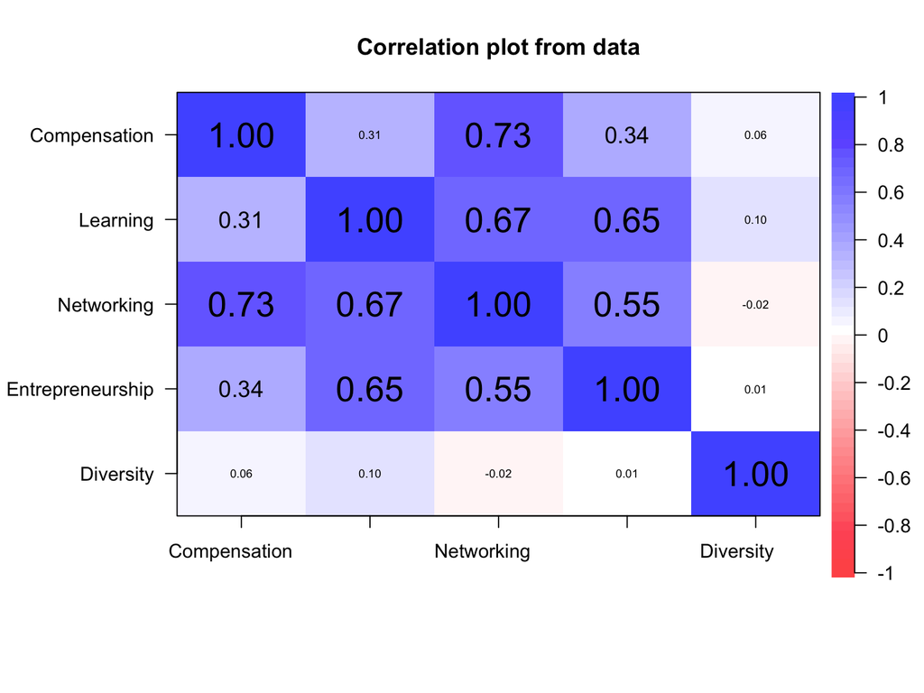

# Multiple Linear Regression without intercept

```
##                  pr_weights MLR_weights
## Compensation           0.36        0.73
## Learning               0.26        0.10
## Networking             0.18        0.02
## Entrepreneurship       0.12        0.05
## Diversity              0.09        0.07
```

```
## the sum of the coefficents =  0.9727114
```

```
## R square =  0.9945974
```

```
## Adjusted R square =  0.9942555
```

# Dr. Jain: “a constrained optimization model that minimizes variances from the published ranking”

Model

$$y = w_1x_1 + w_2x_2 + w_3x_3 + w_4x_4 +
w_5x_5 + \epsilon$$
with $\sum_i w_i = 1$ and $w_i \geq 0$. Then minimize

$$\sum_i (y_i - (w_1x_1 + w_2x_2 + w_3x_3
+ w_4x_4 + w_5x_5))^2$$

# Quadratic Optimization

This problem is a quadratic optimization problem and it is well studied in mathematics

# Back-engineered weights through constrained optimization

```
##                  pr_weights const_weights
## Compensation           0.36          0.74
## Learning               0.26          0.12
## Networking             0.18          0.00
## Entrepreneurship       0.12          0.07
## Diversity              0.09          0.07
```

# Can we counter against multicollinearity?

- Regularization: artifical shrikange of the coefficients

# LASSO model - regularization

```
## R square is  0.9999797
```

```
##                  lasso_weights pr_weights
## Compensation              0.65       0.36
## Learning                  0.04       0.26
## Networking                0.14       0.18
## Entrepreneurship          0.02       0.12
## Diversity                 0.07       0.09
```

# Ridge regression model - regularization

```
## R square is  0.9999798
```

```
##                  ridge_weights pr_weights
## Compensation              0.63       0.36
## Learning                  0.06       0.26
## Networking                0.12       0.18
## Entrepreneurship          0.06       0.12
## Diversity                 0.08       0.09
```

# Compare many models

```
##                  pr_weights Jain_weights lasso_weights ridge_weights
## Compensation           0.36         0.58          0.65          0.63
## Learning               0.26         0.08          0.04          0.06
## Networking             0.18         0.10          0.14          0.12
## Entrepreneurship       0.12         0.08          0.02          0.06
## Diversity              0.09         0.15          0.07          0.08
##                  const_weights MLR_weights
## Compensation              0.74        0.73
## Learning                  0.12        0.10
## Networking                0.00        0.02
## Entrepreneurship          0.07        0.05
## Diversity                 0.07        0.07
```

# Decision Tree

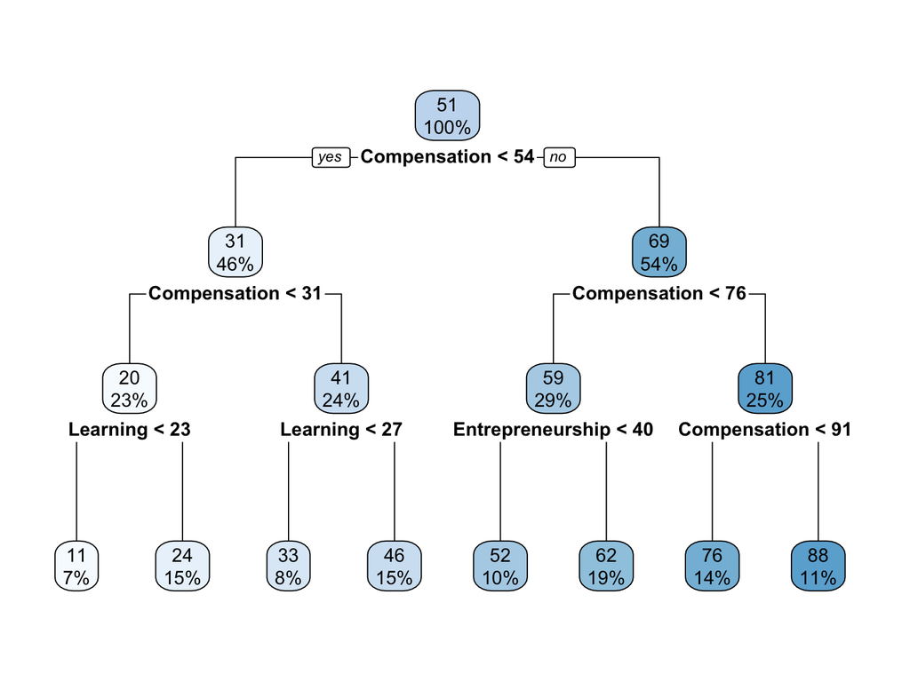

# Decision Tree - important variables

```
##                  m1$variable.importance       perc provided_weights
## Compensation                  41847.861 0.40381234            0.357
## Networking                    26733.308 0.25796395            0.178
## Learning                      12846.825 0.12396587            0.258
## Entrepreneurship              12446.811 0.12010593            0.120
## Diversity                      9757.146 0.09415191            0.086
```

# Bagged (Bootstrap Aggregated) model - important variables

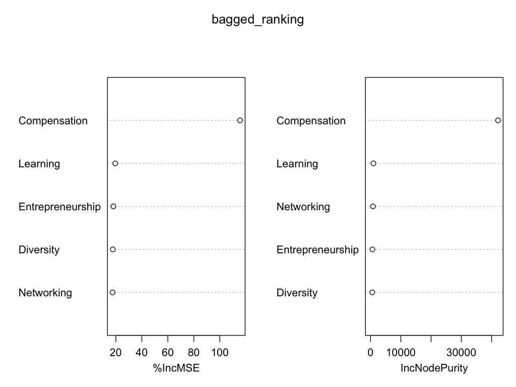

# Conclusion: what happened?

Few possibilities

- BB did not standardize the data (2018, 2019, 2020, 2021)
- Weights provided were not the true weights used
- Methodology is not accurately described
- Provided data is not accurate
- Final score is not linear combination of variables
- What else?